# regression

## Explaining determinants on why and when Governments adopt containment measures against COVID-19

a preliminary study assessing the determinants of the adoption of nation-level NPI policies against the spread of COVID-19  
_non-pharmaceutical-intervention_

**Author 1**, affiliation  
**Author 2**, affiliation  
**Author 3**, affiliation  
*contact information*

30/03/2020, Rome (Italy)

By the time we are writing the recent global virus called COVID-19 has hit more than 190 countries and governments all over the globe have adopted (or are about to adopt) with different timing containment measures in order to limit the devastating effects it is causing to the economy and to people’s health. The disease has already reached a pandemic scale but still many governments hesitate taking action despite it is now clear to all that early or preventive measures can effectively limit the exponential spread.  
Policy interventions include a variety of instruments and most of them imply citizens’ liberties restrictions and this appears to be one of the main drivers refraining governments from intervening. Moreover, besides social and political implications, those tools have also different relative costs and they could be not available for some countries.  
A preventive intervention is key when dealing with these kind of diseases because it mainly allows to flatten the epidemiological curve in order to reduce the infection rate (and consequently losses in human lives) and also manage better the emergency preventing the healthcare systems from overload. The timing of this anticipated intervention is crucial for obtaining better results, as the example figure below shows, anticipation of the policy might obtain greater results in terms of reducing the overall losses created by the exponential spread of the epidemic (see red and green line).

[figure not shown]

But while some governments have been prudent in adopting containment policies, others have immediately taken actions. We study the determinants that should lead government to take more immediate actions over different political and socio-economic sphere, taking into account several considerations suggested by the context:

- Since the clinical consequences of COVID-19 have been found to be more arsh with respect to older population (in particular those aged over 65), countries with an higher fraction of older population should be more concerned, and thus should act faster.
- When deciding on the adoption of NPI policies, a trade off between liberty of citizen and public health concerns emerges, thus country with higher "civil liberties" should have more difficulties in adopting constrainment policies.
- The government needs "data" to justifies containment measures, an higher number of certified confirmed cases and deaths related to covid-19 should ease the adoption of NPI while convincing population to accept them.
- Countries with a more developed Health System can have more toleration on the spread of COVID-19
- media coverage and public opinion could press the government to act.
- strong relationship with affected countries could increase risk of spread and enhance NPI adoption

we also control for peculiar country economic situation measured with GDP per capita, as well the "world evolution" of the spread with time fix effects.

## DATASET coverage

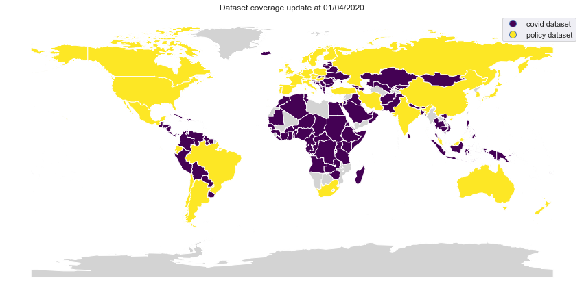

```python
fig,axs=plt.subplots(figsize=(15,10))
mappa_mondo=gpd.read_file("C:\\Users\\gabri\\Desktop\\COVID\\limiti_mondo")
GPD_PLOT=gpd.GeoDataFrame(DATASET_COMPLETE.groupby('ISO3',as_index=False)['geometry'].first())
GPD_PLOT['in_dataset']="covid dataset"
GPD_PLOT['geometry']=GPD_PLOT['geometry'].apply(lambda x:shapely.wkt.loads(x))


GPD_PLOT.set_geometry('geometry',inplace=True)
GPD_PLOT.loc[GPD_PLOT['ISO3'].isin(DATASET['ISO3'].unique()),'in_dataset']="policy dataset"
##sfondo
mappa_mondo.plot(color='lightgrey',ax=axs)
GPD_PLOT.plot('in_dataset',ax=axs,cmap="viridis",legend=True)
axs.set_title('Dataset coverage update at '+datetime.datetime.today().strftime("%d/%m/%Y"));
axs.set_axis_off()
```

## MODELLING FRAMEWORK

In order to estimate the incidence and the statistical significance of the factor associated with policy adoption we made use of "survival analysis"/"Event history Analysis" framework. Our econometric approach uses a cox-time varying regression, where our left-hand variable (the event) is a dummy between 0 and 1 wether the policy has been adopted or not at time *t*.

[figure not shown]

thebaseline component *b*<sub>0</sub>(t) will capture all the world events that vary over time and are not specific to country *i*, while the *x*<sub>i</sub>(t) are our coovariates (i.e. the factors associated with policy adoption), with *B*<sub>i</sub>(t) the coefficients expressing the magnitude of the association.

## RESULTS

We estimate two models for different policy options (the closure of schools and lockdownd policy), and we report the coefficients and the statistical test associated for relevant variable of interest:

- the share of people over 65 years old (_share_65*plus*)
- the number of confirmed and deaths cases due to COVID-19 (_confirmed*cases* & _deaths*cases*)
- the level of civil liberties (*CiviLiberties*)
- the level of attention of the media related to COVID-19 (*trend*)
- the level of the Health System measures with health expenditure (_health_expenditure_per_capita*PPP*)

we further control for the level of income (_GDP*capita*), the geographic location to account for the potential spread of the virus due to climate (*LON*), the potential spread due to relationship with other countries (_GLOB*INDEX*). Our modelling framework also take into account the fact that the two policy options are "incremental" (i.e. shutdown normally comes after closure of schools), thus, when we estimate the model we also control for the adoption of other containment policies (i.e. we control for closure of large events in the "*school closing*" model, and we control for school closure in the "*lockdown model*")

```python
import pandas as pd
from lifelines import CoxTimeVaryingFitter
import datetime
import matplotlib.pyplot as plt
import seaborn as sns;sns.set()
import geopandas as gpd
import shapely.wkt
import os
import folium
from shapely import wkt
import branca.colormap as cm
from branca.element import Template, MacroElement
from matplotlib.patches import Rectangle
from matplotlib.dates import date2num
from folium import plugins
from shapely.ops import cascaded_union
```

```python
folder="D:\\database_vari_miei\\covid_database\\"
db_aggiornato_url=folder+os.listdir(folder)[-1]
db_aggiornato_url
DATASET=pd.read_excel("POLITICAL_COVID_29_03_2020.xlsx",sheet_name="DATA")
### select only useful
DATASET=DATASET.iloc[0:DATASET["ISO3"].last_valid_index()+1,:]
DATASET_COMPLETE=pd.read_csv(db_aggiornato_url,index_col=0,low_memory=False)
# ## list of country for which we have political data
country_analized=DATASET['ISO3'].unique()
policy_var=DATASET.columns
```

```python
def arrange_dataset(dep_var,dep_var_dummy,lista_covariate,control_variable):
    '''
    PARTE COX REGRESSION
    '''
    dep_var='SCHOOL_CLOSING'
    nome_evento=dep_var_dummy
    ## dataset con gli eventi
    # selezionare solo i paesi censiti
    DF=DATASET_COMPLETE.loc[DATASET_COMPLETE['ISO3'].isin(country_analized),:].copy()
    # # rimettere variabile time come pdtimedate
    # # fare gli start and stop (con day - 1)
    DF['stop']=pd.to_datetime(DF['time'])
    DF['start']=DF['stop']-pd.offsets.Day(1)

    country_adopter=list(DF.loc[DF[nome_evento]==1,'ISO3'].unique())
    DF_REGRESSION=pd.DataFrame()

    for paese in DF['ISO3'].unique():
        if paese in country_adopter:
            data_evento=DF.loc[(DF['ISO3']==paese)&(DF[nome_evento]==1),'stop'].min()
            DF_REGRESSION=DF_REGRESSION.append(DF.loc[(DF['ISO3']==paese)&(DF['stop']<=data_evento),:])
        else:
            DF_REGRESSION=DF_REGRESSION.append(DF.loc[(DF['ISO3']==paese),:])
    ### trasforma var in int
    DF_REGRESSION['start']=DF_REGRESSION['start'].apply(lambda x:x.timestamp())
    DF_REGRESSION['stop']=DF_REGRESSION['stop'].apply(lambda x:x.timestamp())

    lista_covariate.extend(control_variable)
    lista_covariate.extend(['start','stop',nome_evento,'ISO3'])

    trend_nulli=DF_REGRESSION.loc[DF_REGRESSION['trend'].isnull(),'time'].min()
    slider_trend_null=(pd.to_datetime(DF_REGRESSION['time'])<trend_nulli)
    DF_REG_NONNULL=DF_REGRESSION.loc[slider_trend_null,lista_covariate]
    ### make percentage in 100 units to facilitate plot interpretation
    DF_REG_NONNULL['share_65_plus']=DF_REG_NONNULL['share_65_plus']*100
    return DF_REG_NONNULL,trend_nulli
```

## descriptive statistics*

```python
descriptive_variable=['share_65_plus','Civilliberties','confirmed_cases','deaths_cases','health_expenditure_per_capita_PPP',
 'trend','GLOB_INDEX','GDP_capita','LON','EVENT_dummy','SCHOOL_CLOSING_dummy','LOCKDOWN_dummy','ISO3']
DATASET_COMPLETE.loc[:,descriptive_variable].describe().round(3)
```

|  | share_65_plus | Civilliberties | confirmed_cases | deaths_cases | health_expenditure_per_capita_PPP | trend | GLOB_INDEX | GDP_capita | LON | EVENT_dummy | SCHOOL_CLOSING_dummy | LOCKDOWN_dummy |
| --- | --- | --- | --- | --- | --- | --- | --- | --- | --- | --- | --- | --- |
| count | 10403.000 | 9782.000 | 10671.000 | 10671.000 | 10334.000 | 10519.000 | 10464.000 | 10395.000 | 10671.000 | 2622.000 | 2622.000 | 2622.000 |
| mean | 0.099 | 5.982 | 908.329 | 36.677 | 1054.040 | 17.238 | 13783.315 | 23892.627 | 17.296 | 0.195 | 0.227 | 0.114 |
| std | 0.067 | 2.532 | 7141.693 | 372.865 | 1349.173 | 26.632 | 18611.044 | 22391.104 | 59.178 | 0.396 | 0.419 | 0.317 |
| min | 0.013 | 0.880 | 0.000 | 0.000 | 4.624 | 0.000 | 0.244 | 822.552 | -109.433 | 0.000 | 0.000 | 0.000 |
| 25% | 0.036 | 3.820 | 0.000 | 0.000 | 95.530 | 0.000 | 2989.564 | 6752.384 | -8.152 | 0.000 | 0.000 | 0.000 |
| 50% | 0.076 | 6.325 | 0.000 | 0.000 | 502.864 | 1.000 | 7318.252 | 16461.794 | 19.401 | 0.000 | 0.000 | 0.000 |
| 75% | 0.158 | 8.240 | 14.000 | 0.000 | 1411.563 | 27.000 | 16677.837 | 35852.914 | 47.376 | 0.000 | 0.000 | 0.000 |
| max | 0.284 | 10.000 | 161807.000 | 11591.000 | 7749.948 | 100.000 | 196562.358 | 132886.395 | 177.974 | 1.000 | 1.000 | 1.000 |

**please note that descriptive statistics are referred to the whole dataset. The input of the cox regression is limited, for each country, till when the dummy response turn to be true*. for a simple explanation see http://www.math.ucsd.edu/~rxu/math284/slect7.pdf

```python
dep_var='SCHOOL_CLOSING'
dep_var_dummy=dep_var+"_dummy"
### aggiungere latitudine o longitudine per avere il control sul meteo
lista_covariate=['share_65_plus','Civilliberties','confirmed_cases','deaths_cases',"health_expenditure_per_capita_PPP",'trend','GLOB_INDEX']
### aggiungere altri eventi dummies
control_variable=["GDP_capita","LON"]
event_variable_control=["EVENT_dummy"]
control_variable.extend(event_variable_control)
DF_REG_NONNULL,trend_nulli=arrange_dataset(dep_var=dep_var,dep_var_dummy=dep_var_dummy,lista_covariate=lista_covariate,control_variable=control_variable)
#DF_REG_NONNULL.loc[:,DF_REG_NONNULL.columns.difference(['start','stop'])].describe().round(3)
```

## Model 1: school closures

```python
ctv = CoxTimeVaryingFitter()
ctv.fit(DF_REG_NONNULL, id_col="ISO3", event_col=dep_var_dummy, start_col="start", stop_col="stop", show_progress=True)
print("Non null observations till "+trend_nulli)
ctv.print_summary(decimals=2)
```

```
Iteration 5: norm_delta = 0.00012, step_size = 1.00000, ll = -88.70516, newton_decrement = 0.00000, seconds_since_start = 0.0Convergence completed after 5 iterations.
Non null observations till 2020/03/30
```

| model | lifelines.CoxTimeVaryingFitter |
| --- | --- |
| event col | 'SCHOOL_CLOSING_dummy' |
| number of subjects | 38 |
| number of periods | 2055 |
| number of events | 33 |
| partial log-likelihood | -88.71 |
| time fit was run | 2020-04-01 09:09:54 UTC |

|  | coef | exp(coef) | se(coef) | coef lower 95% | coef upper 95% | exp(coef) lower 95% | exp(coef) upper 95% | z | p | -log2(p) |
| --- | --- | --- | --- | --- | --- | --- | --- | --- | --- | --- |
| share_65_plus | 0.12 | 1.13 | 0.06 | 0.01 | 0.23 | 1.01 | 1.26 | 2.19 | 0.03 | 5.13 |
| Civilliberties | -0.26 | 0.77 | 0.12 | -0.50 | -0.03 | 0.61 | 0.97 | -2.17 | 0.03 | 5.08 |
| confirmed_cases | -0.00 | 1.00 | 0.00 | -0.00 | 0.00 | 1.00 | 1.00 | -0.45 | 0.66 | 0.61 |
| deaths_cases | 0.00 | 1.00 | 0.01 | -0.01 | 0.01 | 0.99 | 1.01 | 0.60 | 0.55 | 0.86 |
| health_expenditure_per_capita_PPP | 0.00 | 1.00 | 0.00 | -0.00 | 0.00 | 1.00 | 1.00 | 0.72 | 0.47 | 1.08 |
| trend | 0.01 | 1.01 | 0.01 | -0.02 | 0.03 | 0.99 | 1.03 | 0.57 | 0.57 | 0.82 |
| GLOB_INDEX | 0.00 | 1.00 | 0.00 | -0.00 | 0.00 | 1.00 | 1.00 | 0.79 | 0.43 | 1.22 |
| GDP_capita | -0.00 | 1.00 | 0.00 | -0.00 | 0.00 | 1.00 | 1.00 | -1.49 | 0.14 | 2.86 |
| LON | 0.00 | 1.00 | 0.00 | -0.00 | 0.01 | 1.00 | 1.01 | 1.25 | 0.21 | 2.24 |
| EVENT_dummy | 1.04 | 2.84 | 0.42 | 0.21 | 1.88 | 1.24 | 6.54 | 2.46 | 0.01 | 6.17 |

| Log-likelihood ratio test | 18.95 on 10 df, -log2(p)=4.61 |
| --- | --- |

## Model 2: lockdown

```python
dep_var='LOCKDOWN'
dep_var_dummy=dep_var+"_dummy"
### aggiungere latitudine o longitudine per avere il control sul meteo
lista_covariate=['share_65_plus','Civilliberties','confirmed_cases','deaths_cases',"health_expenditure_per_capita_PPP",'trend','GLOB_INDEX']
### aggiungere altri eventi dummies
control_variable=["GDP_capita","LON"]
event_variable_control=["EVENT_dummy",'SCHOOL_CLOSING_dummy']
control_variable.extend(event_variable_control)
DF_REG_NONNULL,trend_nulli=arrange_dataset(dep_var=dep_var,dep_var_dummy=dep_var_dummy,lista_covariate=lista_covariate,control_variable=control_variable)
```

```python
ctv = CoxTimeVaryingFitter()
ctv.fit(DF_REG_NONNULL, id_col="ISO3", event_col=dep_var_dummy, start_col="start", stop_col="stop", show_progress=True)
print("Non null observations till "+trend_nulli)
ctv.print_summary(decimals=2)
```

```
Iteration 7: norm_delta = 0.00000, step_size = 1.00000, ll = -37.52922, newton_decrement = 0.00000, seconds_since_start = 0.0Convergence completed after 7 iterations.
Non null observations till 2020/03/30
```

| model | lifelines.CoxTimeVaryingFitter |
| --- | --- |
| event col | 'LOCKDOWN_dummy' |
| number of subjects | 38 |
| number of periods | 2325 |
| number of events | 19 |
| partial log-likelihood | -37.53 |
| time fit was run | 2020-04-01 09:12:45 UTC |

|  | coef | exp(coef) | se(coef) | coef lower 95% | coef upper 95% | exp(coef) lower 95% | exp(coef) upper 95% | z | p | -log2(p) |
| --- | --- | --- | --- | --- | --- | --- | --- | --- | --- | --- |
| share_65_plus | -0.09 | 0.91 | 0.08 | -0.26 | 0.07 | 0.77 | 1.07 | -1.13 | 0.26 | 1.96 |
| Civilliberties | 0.06 | 1.06 | 0.19 | -0.31 | 0.43 | 0.73 | 1.54 | 0.31 | 0.75 | 0.41 |
| confirmed_cases | -0.00 | 1.00 | 0.00 | -0.00 | 0.00 | 1.00 | 1.00 | -1.81 | 0.07 | 3.83 |
| deaths_cases | 0.01 | 1.01 | 0.00 | 0.00 | 0.02 | 1.00 | 1.02 | 2.36 | 0.02 | 5.79 |
| health_expenditure_per_capita_PPP | 0.00 | 1.00 | 0.00 | -0.00 | 0.00 | 1.00 | 1.00 | 1.04 | 0.30 | 1.74 |
| trend | 0.06 | 1.06 | 0.02 | 0.02 | 0.09 | 1.02 | 1.09 | 3.45 | <0.005 | 10.80 |
| GLOB_INDEX | -0.00 | 1.00 | 0.00 | -0.00 | 0.00 | 1.00 | 1.00 | -1.54 | 0.12 | 3.01 |
| GDP_capita | -0.00 | 1.00 | 0.00 | -0.00 | 0.00 | 1.00 | 1.00 | -1.16 | 0.25 | 2.02 |
| LON | 0.01 | 1.01 | 0.00 | -0.00 | 0.02 | 1.00 | 1.02 | 1.73 | 0.08 | 3.59 |
| EVENT_dummy | 1.77 | 5.86 | 0.73 | 0.34 | 3.20 | 1.40 | 24.53 | 2.42 | 0.02 | 6.02 |
| SCHOOL_CLOSING_dummy | 3.10 | 22.20 | 0.95 | 1.23 | 4.97 | 3.43 | 143.70 | 3.25 | <0.005 | 9.78 |

| Log-likelihood ratio test | 52.20 on 11 df, -log2(p)=21.93 |
| --- | --- |

## References

##### lifelines package

Cameron Davidson-Pilon, Jonas Kalderstam, Noah Jacobson, Paul Zivich, Ben Kuhn, Mike Williamson, … Abraham Flaxman. (2020, March 25). CamDavidsonPilon/lifelines: v0.24.3 (Version v0.24.3). Zenodo. http://doi.org/10.5281/zenodo.3727281

##### other articles to cite:

- imperial college effect of containment measures
- dataset article
- John Hopkins dataset

# Appendix

### Analysis of missing values

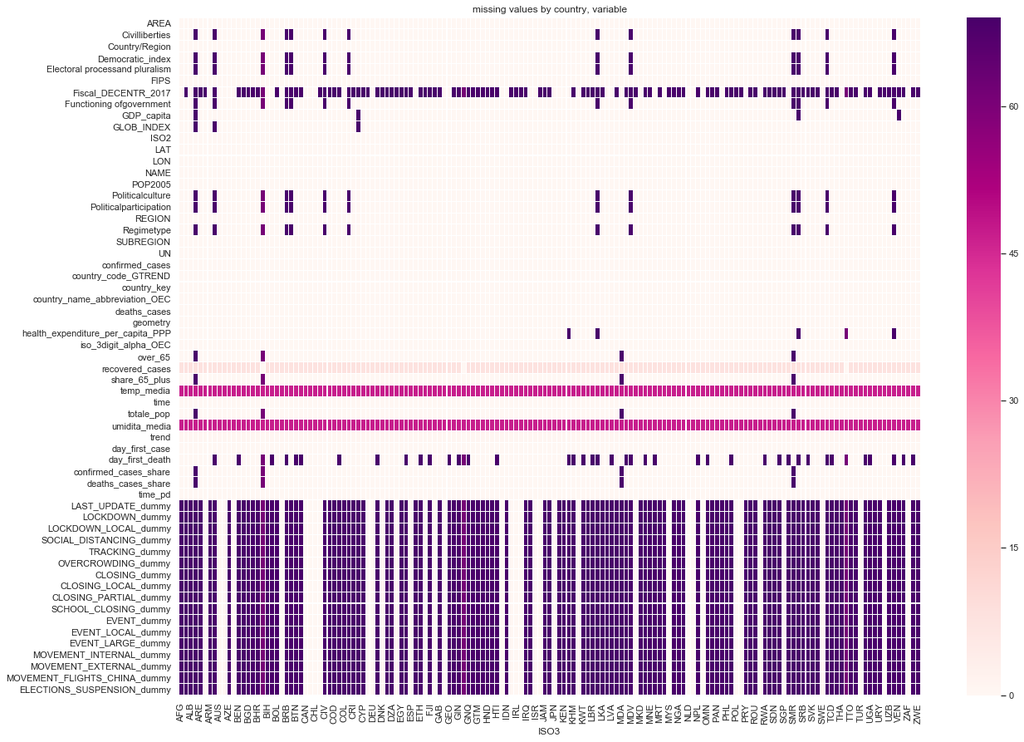

```python
## exclude policy var for which the na have other meaning
NV=DATASET_COMPLETE.loc[:,~(DATASET_COMPLETE.columns.isin(policy_var))].isnull()
NV.loc[:,'ISO3']=DATASET_COMPLETE.loc[:,'ISO3']
fig,axs=plt.subplots(figsize=(20,15))
sns.heatmap(NV.groupby('ISO3').sum().transpose(),cmap="RdPu",linewidths=0.05, linecolor='white');
axs.set_title("missing values by country, variable");
```

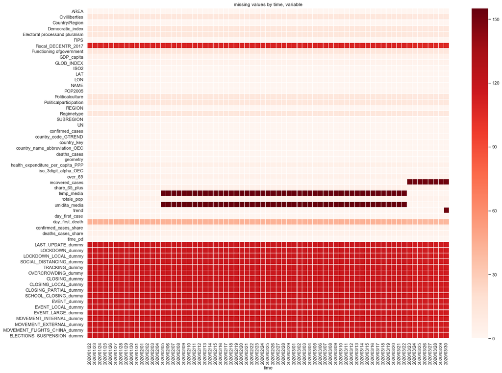

```python
NV=DATASET_COMPLETE.loc[:,~(DATASET_COMPLETE.columns.isin(policy_var))].isnull()
NV.loc[:,'time']=DATASET_COMPLETE.loc[:,'time']
fig,axs=plt.subplots(figsize=(20,15))
sns.heatmap(NV.groupby('time').sum().transpose(),cmap="Reds",linewidths=0.05, linecolor='white');
axs.set_title("missing values by time, variable");
```

## Globalization index

[figure not shown]

```python
from IPython.display import HTML

HTML('''<script>
code_show=true;
function code_toggle() {
 if (code_show){
 $('div.input').hide();
 } else {
 $('div.input').show();
 }
 code_show = !code_show
}
$( document ).ready(code_toggle);
</script>
<form action="javascript:code_toggle()"><input type="submit" value="Click here to toggle on/off the raw code."></form>''')
```